# Practice_3

```python
# импорт библиотеки pandas
import pandas as pd


# считывание CSV-файла в датафрейм pandas
df = pd.read_csv('real_estate.csv')

# вывод первых 10 строк датафрейма
print(df.head(10)) #df.tail()
```

```
   total_area  living_area  ceil_height  rooms_number  city_center_distance  \
0        72.0         39.6          2.8           3.0                   4.1
1        61.9         32.2          2.8           2.0                   8.2
2       122.0         54.9          3.1           5.0                   8.1
3        57.9         31.8          3.2           1.0                   3.4
4       140.0         61.6          2.8           4.0                   5.0
5       104.4         55.3          2.9           5.0                   8.5
6       153.0         87.2          3.0           7.0                   5.2
7        62.1         40.4          2.7           2.0                  11.4
8        53.0         22.8          2.9           1.0                   3.5
9        97.0         48.5          3.0           3.0                   6.7

   years_after_repair      price
0                 8.0  4819200.0
1                 4.0  3736870.0
2                 0.0  8598200.0
3                 9.0  2552410.0
4                 4.0  8570000.0
5                 6.0  5999040.0
6                11.0  8158500.0
7                 5.0  3177510.0
8                 7.0  3555200.0
9                 4.0  5427200.0
```

```python
# считывание CSV-файла в датафрейм pandas
#df = pd.read_csv('real_estate_data.csv', sep = '\t')

# вывод первых 10 строк датафрейма
#print(df.head(10))
```

[output not shown]

```python
print(df.shape)
```

```
(10000, 7)
```

```python
# вывод сводной информации о датафрейме
print(df.info())
```

```
<class 'pandas.core.frame.DataFrame'>
RangeIndex: 10000 entries, 0 to 9999
Data columns (total 7 columns):
 #   Column                Non-Null Count  Dtype
---  ------                --------------  -----
 0   total_area            9999 non-null   float64
 1   living_area           9999 non-null   float64
 2   ceil_height           9999 non-null   float64
 3   rooms_number          9999 non-null   float64
 4   city_center_distance  9999 non-null   float64
 5   years_after_repair    9999 non-null   float64
 6   price                 9999 non-null   float64
dtypes: float64(7)
memory usage: 547.0 KB
None
```

```python
# вывод строки с пропуском в признаке total_area
print(df.loc[df['total_area'].isna()])
```

```
      total_area  living_area  ceil_height  rooms_number  \
3548         NaN          NaN          NaN           NaN

      city_center_distance  years_after_repair  price
3548                   NaN                 NaN    NaN
```

```python
# удаление пропусков
df = df.dropna()

# вывод размерности датафрейма
print(df.shape)
```

```
(9999, 7)
```

```python
# вывод описательных статистик
print(df.describe())
```

```
        total_area  living_area  ceil_height  rooms_number  \
count  9999.000000  9999.000000  9999.000000   9999.000000
mean     72.159916    37.918622     2.934603      2.632863
std      21.642565    12.605736     0.226841      1.015544
min      23.200000    10.800000     2.700000      1.000000
25%      61.000000    29.900000     2.700000      2.000000
50%      66.300000    35.300000     2.900000      3.000000
75%      75.800000    42.000000     3.100000      3.000000
max     217.000000   130.000000     3.500000      8.000000

       city_center_distance  years_after_repair         price
count           9999.000000         9999.000000  9.999000e+03
mean               6.110211            5.698470  4.169913e+06
std                2.739951            4.123129  1.383774e+06
min                0.000000            0.000000  0.000000e+00
25%                4.200000            3.000000  3.288825e+06
50%                6.100000            5.000000  3.956840e+06
75%                8.000000            8.000000  4.686765e+06
max               13.800000           19.000000  1.363000e+07
```

```python
# вывод строк, в которых значения признака price равны 0
print(df[df.price == 0])

# удаление строк, в которых значения признака price равны 0
df = df.loc[df['price'] != 0]

# вывод описательных статистик
print(df.describe())
```

```
      total_area  living_area  ceil_height  rooms_number  \
3009        62.3         27.4          2.8           3.0
6736        75.0         33.0          2.8           4.0

      city_center_distance  years_after_repair  price
3009                   5.2                 3.0    0.0
6736                   3.0                 8.0    0.0
        total_area  living_area  ceil_height  rooms_number  \
count  9997.000000  9997.000000  9997.000000   9997.000000
mean     72.160618    37.920166     2.934630      2.632690
std      21.644487    12.606462     0.226856      1.015547
min      23.200000    10.800000     2.700000      1.000000
25%      61.000000    29.900000     2.700000      2.000000
50%      66.300000    35.300000     2.900000      3.000000
75%      75.800000    42.000000     3.100000      3.000000
max     217.000000   130.000000     3.500000      8.000000

       city_center_distance  years_after_repair         price
count           9997.000000         9997.000000  9.997000e+03
mean               6.110613            5.698510  4.170747e+06
std                2.740033            4.123388  1.382654e+06
min                0.000000            0.000000  8.228800e+05
25%                4.200000            3.000000  3.289500e+06
50%                6.100000            5.000000  3.957010e+06
75%                8.000000            8.000000  4.686800e+06
max               13.800000           19.000000  1.363000e+07
```

```python
# вывод количества дубликатов
print(df.duplicated().sum())

# удаление дубликатов
df = df.drop_duplicates()

# вывод размерности датафрейма
print(df.shape)
```

```
564
(9433, 7)
```

```python
# сохранение входных признаков в переменную X
X = df.drop('price', axis=1)

# вывод первых пяти объектов переменной X
print(X.head())

# сохранение целевого признака в переменную y
y = df['price']

# вывод первых пяти значений переменной y
print(y.head())
```

```
   total_area  living_area  ceil_height  rooms_number  city_center_distance  \
0        72.0         39.6          2.8           3.0                   4.1
1        61.9         32.2          2.8           2.0                   8.2
2       122.0         54.9          3.1           5.0                   8.1
3        57.9         31.8          3.2           1.0                   3.4
4       140.0         61.6          2.8           4.0                   5.0

   years_after_repair
0                 8.0
1                 4.0
2                 0.0
3                 9.0
4                 4.0
0    4819200.0
1    3736870.0
2    8598200.0
3    2552410.0
4    8570000.0
Name: price, dtype: float64
```

```python
#https://github.com/scikit-learn/scikit-learn
!pip install scikit-learn
```

[output not shown]

```python
# импорт библиотеки sklearn
import sklearn

# вывод установленной версии библиотеки
print(sklearn.__version__)
```

```
1.7.2
```

"Надо добавить в функцию именованный аргумент `random_state`, чтобы при каждом перезапуске кода датасет делился на выборки одинаково. `train_test_split()` разбивает наблюдения по частям рандомно — в тестовую выборку всегда будет попадать, к примеру, четверть строк, но из разных мест в таблице. Если перезапустить блокнот, система повторит это действие. Она поделит данные в прежнем соотношении, но в выборки случайным образом попадут другие строки, а значит, модель отработает с новым результатом. В итоге это приведёт к тому, что данные для обучения и тестирования модели пересекутся, и сделать выводы об этих процедурах будет невозможно. Чтобы такого не случилось, нужно зафиксировать деление датасета на выборки по конкретным строкам. Это и делает аргумент `random_state`."

```python
# импорт метода train_test_split
from sklearn.model_selection import train_test_split

# создание константы RANDOM_STATE
RANDOM_STATE = 42

# разделение на тренировочную и тестовую выборки
X_train, X_test, y_train, y_test = train_test_split(
    X, y, random_state=RANDOM_STATE
)

# вывод необходимых размерностей
print(X_train.shape)
print(X_test.shape)
print(y_train.shape)
print(y_test.shape)
```

```
(7074, 6)
(2359, 6)
(7074,)
(2359,)
```

```python
#класс, который позволяет создать модель линейной регрессии
from sklearn.linear_model import LinearRegression
```

```python
model_lr = LinearRegression()
```

Обучение модели В классе `LinearRegression` метод `fit()`, который позволяет получить и запомнить оптимальные значения коэффициентов.

```python
model_lr.fit(X_train, y_train)
```

```
LinearRegression()
```

```python
# вывод рассчитанных коэффициентов
print(model_lr.intercept_, model_lr.coef_)
```

```
-472791.7031396297 [ 58467.40537231  -7651.77393412 387841.47927182  55630.34052642
 -47147.23876167 -49522.38415641]
```

В классе `LinearRegression` есть метод `predict()`, который позволяет предсказать целевой признак по рассчитанным коэффициентам.

```python
predictions = model_lr.predict(X_test)
```

```python
# вывод вторых предсказанного и настоящего значений
print(predictions[0], y_test.reset_index(drop=True)[0])
```

```
6075621.997725401 6129680.0
```

```python
#красивый код, где все в одном месте
'''
# необходимые импорты
import pandas as pd

from sklearn.linear_model import LinearRegression
from sklearn.model_selection import train_test_split


# создание константы RANDOM_STATE
RANDOM_STATE = 42


# считывание CSV-файла в датафрейм pandas, сохранение выборок
df = pd.read_csv('real_estate.csv')
X = df.drop('price', axis=1)
y = df['price']
X_train, X_test, y_train, y_test = train_test_split(
    X,
    y,
    random_state=RANDOM_STATE
)


# инициализация и обучение модели
model_lr  = LinearRegression()
model_lr.fit(X_train, y_train)

# предсказанные значения для X_test
predictions = model_lr.predict(X_test)

# вывод вторых предсказанного и настоящего значений
print(predictions[1], y_test.reset_index(drop=True)[1])

'''
```

# Матрица корреляции

```python
print(df.corr())
```

```
                      total_area  living_area  ceil_height  rooms_number  \
total_area              1.000000     0.893997    -0.003698      0.762376
living_area             0.893997     1.000000     0.001148      0.683558
ceil_height            -0.003698     0.001148     1.000000     -0.008103
rooms_number            0.762376     0.683558    -0.008103      1.000000
city_center_distance    0.015211     0.011322     0.000223      0.013688
years_after_repair     -0.012738    -0.015997     0.003032     -0.006658
price                   0.888296     0.780817     0.057126      0.691411

                      city_center_distance  years_after_repair     price
total_area                        0.015211           -0.012738  0.888296
living_area                       0.011322           -0.015997  0.780817
ceil_height                       0.000223            0.003032  0.057126
rooms_number                      0.013688           -0.006658  0.691411
city_center_distance              1.000000           -0.007749 -0.078439
years_after_repair               -0.007749            1.000000 -0.158384
price                            -0.078439           -0.158384  1.000000
```

```python
!pip install seaborn
```

```
  Using cached seaborn-0.13.2-py3-none-any.whl.metadata (5.4 kB)
Using cached seaborn-0.13.2-py3-none-any.whl (294 kB)
```

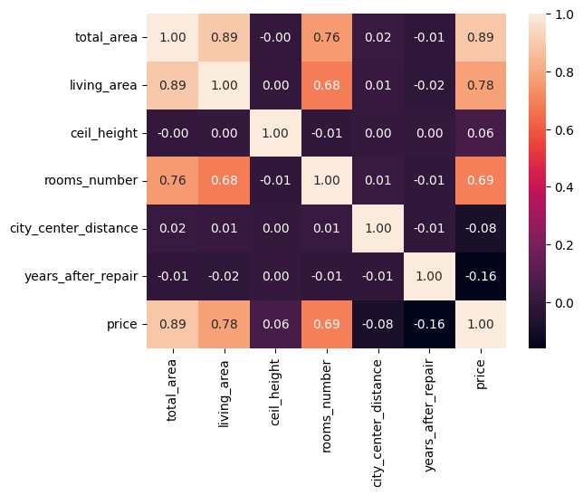

```python
# импорт библиотеки seaborn
import seaborn as sns
# построение тепловой карты
sns.heatmap(df.corr(), annot=True, fmt='.2f')
```

```python
# необходимые импорты
import pandas as pd

from sklearn.linear_model import LinearRegression
from sklearn.model_selection import train_test_split


# создание константы RANDOM_STATE
RANDOM_STATE = 42


# считывание CSV-файла в датафрейм pandas, сохранение выборок
df = pd.read_csv('real_estate_clean.csv')
X = df.drop('price', axis=1)
y = df['price']
X_train, X_test, y_train, y_test = train_test_split(
    X,
    y,
    random_state=RANDOM_STATE
)

# инициализация и обучение модели
model_lr  = LinearRegression()
model_lr.fit(X_train, y_train)

# предсказанные значения для X_test
predictions = model_lr.predict(X_test)

# вывод первых предсказанного и настоящего значений
print(predictions[1], y_test.reset_index(drop=True)[1])
```

```
1661225.3759378106 2109540.0
```

# Оценка качества

```python
from sklearn.metrics import mean_squared_error
```

```python
# получение значения MSE
mse = mean_squared_error(predictions, y_test)


# вывод полученного значения MSE
print(mse)
```

```
327342872169.86914
```

В предсказании цены квартир модель в среднем ошибается на 327342872169.86914 (руб2)

```python
# получение значения RMSE
#rmse = mean_squared_error(predictions, y_test, squared=False)
rmse = mean_squared_error(predictions, y_test, squared=False)

# вывод полученного значения RMSE
print(rmse)
```

[output not shown]

```python
import sklearn
print(sklearn.__version__)
```

```
1.7.2
```

```python
!pip install --upgrade scikit-learn
```

```python
help(mean_squared_error)
```

[output not shown]

```python
import numpy as np
rmse = np.sqrt(mse)
print(rmse)
```

```
572138.8574200053
```

```python
# необходимые импорты
import pandas as pd

from sklearn.linear_model import LinearRegression
from sklearn.metrics import mean_squared_error
from sklearn.model_selection import train_test_split

# создание константы RANDOM_STATE
RANDOM_STATE = 42


# считывание CSV-файла в датафрейм pandas, сохранение выборок
df = pd.read_csv('real_estate_clean.csv')
X = df.drop('price', axis=1)
y = df['price']
X_train, X_test, y_train, y_test = train_test_split(
    X,
    y,
    random_state=RANDOM_STATE
)

# инициализация и обучение модели, получение предсказания
model_lr  = LinearRegression()
model_lr.fit(X_train, y_train)
predictions = model_lr.predict(X_test)

# получение значения RMSE
rmse = mean_squared_error(predictions, y_test, squared=False)

# вывод полученного значения RMSE
print(rmse)
```

[output not shown]